This notebook is to represent the initial exploration of Moody’s Sample Data.

1. Looking at the classes of the variables and its distribution

```r
sapply(Data_20new_20funding,class)
```

[output not shown]

So a mix of numeric, Posixct and character variables are found here.

2. Looking at the summary level of the data

```r
summary(Data_20new_20funding)
```

[output not shown]

3. Let us also look at the standard deviation of each of the numeric attributes in the dataset

```r
sapply(Data_20new_20funding,sd)
```

[output not shown]

4. Let us look at some histograms for each of the data element

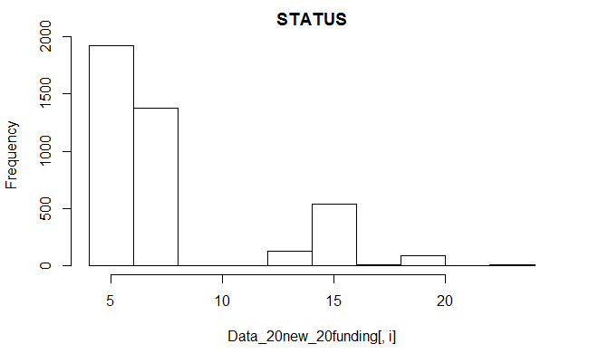

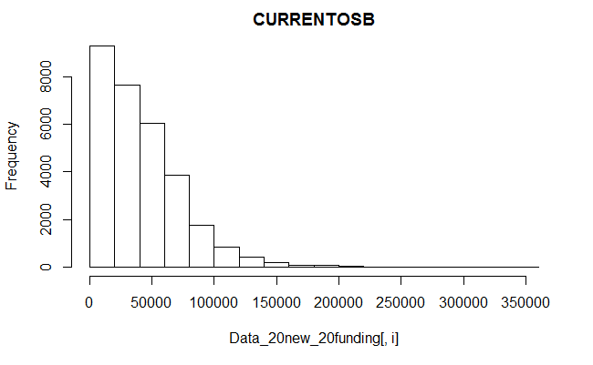

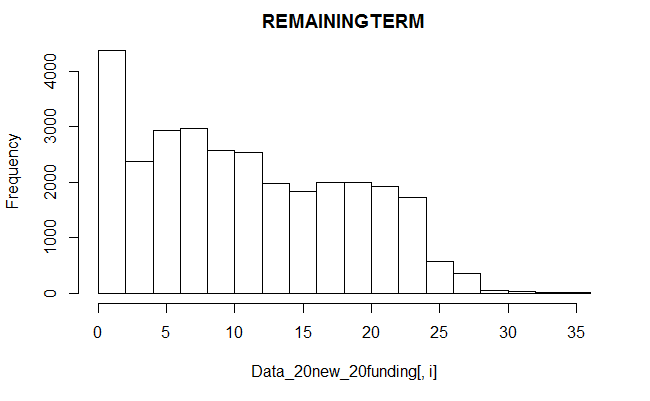

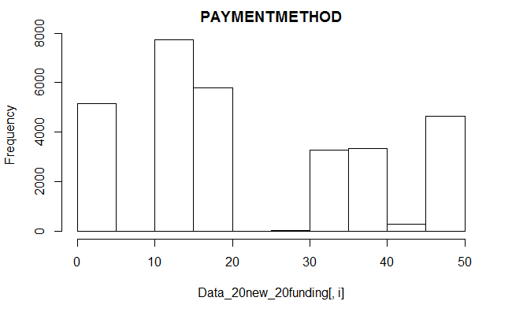

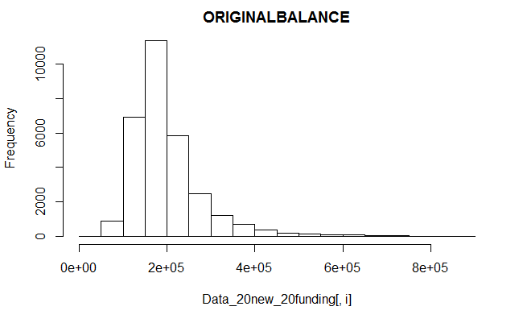

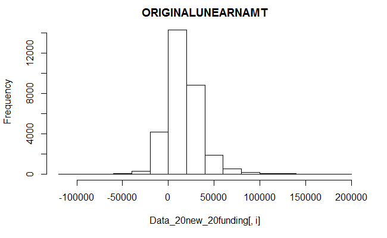

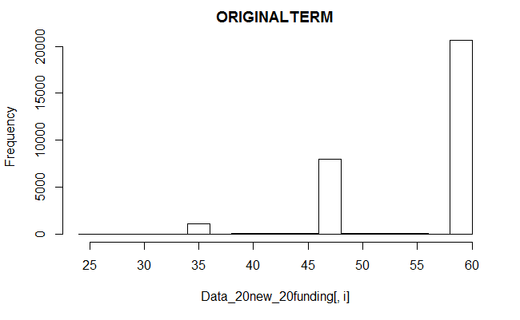

```r
#,42:47,50 ,12:31,35:40
for(i in c(4:10)){

  hist(Data_20new_20funding[,i],main=names(Data_20new_20funding)[i])

}
```

```r
library(lattice)

Data_20new_20funding <- data.frame(Data_20new_20funding)
str(iris[,4])
hist(Data_20new_20funding[,4])
```

[output not shown]

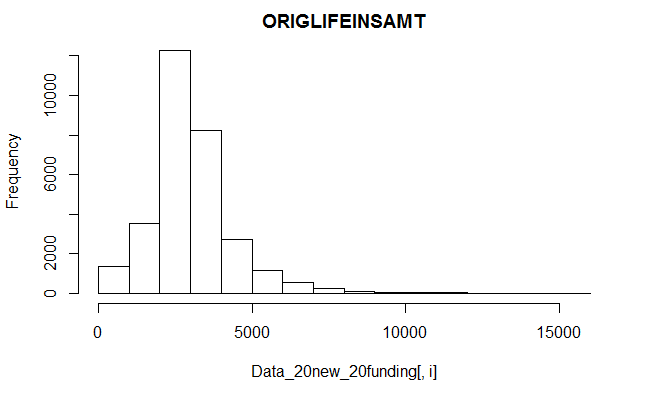

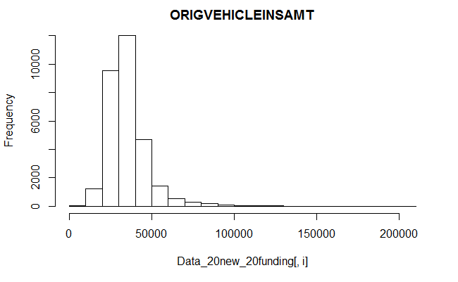

[figure not shown]

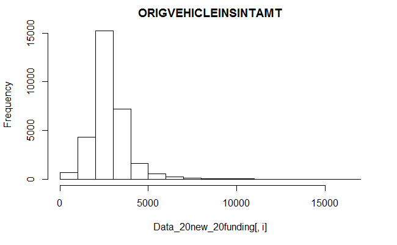

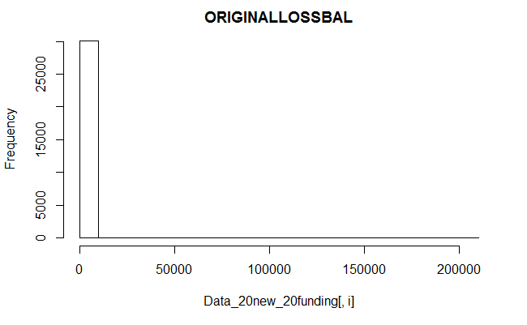

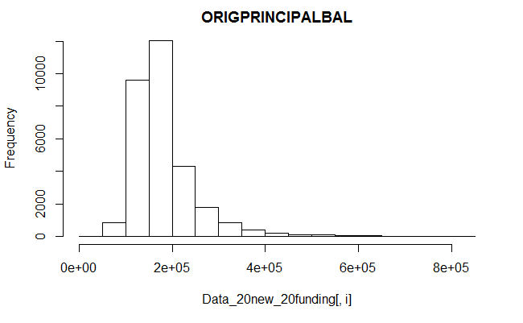

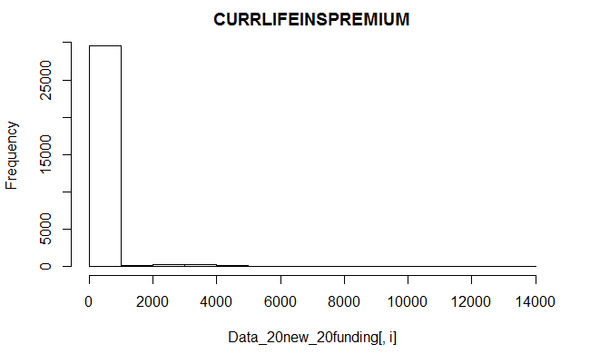

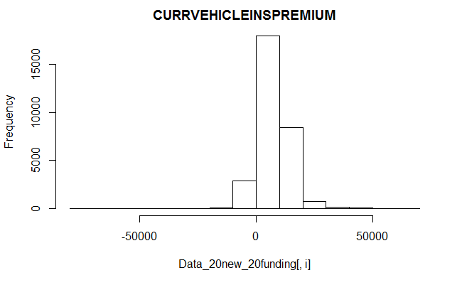

[figure not shown]

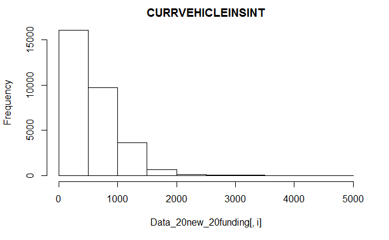

[figure not shown]

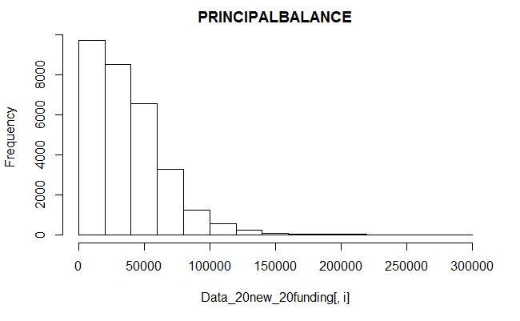

[10 more figures not shown]

```r
#,42:47,50 ,12:31,35:40
for(i in c(12:33)){

  hist(Data_20new_20funding[,i],main=names(Data_20new_20funding)[i])

}
```

```r
library(dplyr)
library(ggplot2)
```

Let us now start with some initial exploration of the data for Moodys

# Current outstanding balance : Remaining term

Let us look at cases where there is current outstanding and the remaining term is 0. This could indicate cases where people have not been able to close their existing loan even after the end of their tenure.

```r
COSB_expl1 <- Data_20new_20funding %>% filter(CURRENTOSB > 0 & REMAININGTERM ==0)
```

There are around 268 records.

[output not shown]

```r
COSB_expl1 %>% filter(IRREGACCTIND==1) %>% summarise(mean(DAYSPASTDUE,na.rm=TRUE))

COSB_expl1 %>% filter(IRREGACCTIND!=1) %>% summarise(mean(DAYSPASTDUE,na.rm=TRUE))
```

[output not shown]

| mean(DAYSPASTDUE, na.rm = TRUE) |
| --- |
| 7.61 |

1. Original Contract date + Original term > Current date : This it is prepayment. Can look at how many days of prepayment has it done ?
2. Looking at ranges of Days past due where Remaining term is 0. How can this happen ?? : ranges 0 and 332 , mean 8.14
3. Are there any original loss balances in these cases ? : No none of them 4: How many cases have Days past due dates out of 268 cases : ONly 54 out of 268 have such cases 5: What is the mean, mode and ranges of the credit scores for this cases and how it compares with the general cases : Not much difference between all these cases 6: What is the difference between the scheduled balance and actual balance ? If the difference is -ve ( scheduled - actual) it is a concern if comparison with the original balance is significant : Only 19 cases have -ve balance which is only 7%. Need to compare with other general case. For general it is around 12%. That means 12% of cases lag behind in terms of actual repayment.
4. Do those cases where the scheduled balance to COB is negative , how does it fare in terms of the Days past due ? : For the filtered data set -ve cases has a mean Days past due as 69 and +ve cases has around 3. For the general cases, -ve cases has around 91 and +ve cases have around 2.68. So the scheduled balance - COB could be a good comparison for delinquency.
5. Looking at Irregular account indicator flag : Irregular indicator and Days past due dosent mean anything

# Relationship between the POOl ID and many other variables

Some of the relationship which can be studied are the following 1. Pool ID v/s delinquncy rates 2. Pool ID v/s prepayment( Original contract + original term , period left, current balance, current term etc) 3. Pool ID v/s scheduled balance - current balance